# Hyne - Logs - Green and Dry

JH

# 1 Dataset

## 1.1 Boards

```r
library(subselect)
library(glmulti)
library(leaps)
library(lattice)
library(gridExtra)
```

```r
library(ggplot2)
library(randomForest)
library(MASS)
library(RODBC)
ch = odbcConnect('Hyne',uid='sa',pwd="password12")

mypanel = function(x,y,...) {
  panel.abline(c(0,1), col='grey70', lty=2)
  panel.xyplot(x,y,...)
}

B = sqlQuery(ch, "
             select
                m.flitchId,
                SWILogNumber,
                g.MOE [E.g],
                g.Density [den.g],
                m.swv [v.d.hitman],
                h.[Density_kg/m3] [den.d.lhg],
                h.[MOE.cltraw] [E.d.clt],
                m.pith,
                m.wane,
                m.bow,
                m.crook,
                m.twist,
                m.inCant,
                X_Dens [den.d.chh],
                X_Clear [den.d.chh.clear],
                X_DynE [E.d.chh.dyn],
                X_AvgE [E.d.chh.avg],
                X_MOE [E.d.chh.moe],
                X_min [chh.grade.min],
                X_max [chh.grade.max],
                xc, yc
             from (
                select
                  flitchId,
                  max(pith) pith,
                  max(wane) wane,
                  avg(swv) swv,
                  avg(bow) bow,
                  avg(crook) crook,
                  avg(twist) twist,
                  max(inCant) inCant
                from manualMeas group by flitchId
             ) m
             left join CHHBoards c on c.flitchId=m.flitchId
             left join HyneDryBoards h on h.flitchId=m.flitchId
             left join ecoustic g on m.flitchId=g.flitchId
             left join (
                select
                  flitchId,
                  max(SWILogNumber) SWILogNumber
                from
                  boardEndImages i, barcode_image bi, boardEndBarcodes b
                where flitchId is not null and i.id=bi.imageId and bi.barcodeId=b.id group by flitchId
             ) f on f.flitchId=m.flitchId
             left join (
                select FlitchID, avg(boardCentroidX_mm) xc, avg(boardCentroidY_mm) yc
                from boardEndBarcodes b, boardEndImages i, barcode_image bi
                where b.id=bi.barcodeId and i.id=bi.imageId
                group by FlitchID
             ) xy on xy.FlitchID=m.flitchId
             ")
B$pith_wane = paste(B$pith,B$wane)
B$E.d.hitman = B$v.d^2*B$den.d.chh/1e9

# halve the SWV for ridiculosly fast ecoustic velocities
B$v.g = sqrt(B$E.g*1e9/B$den.g)
B$E.g.corrected = B$E.g
ii=!is.na(B$v.g) & B$v.g>4000
B$E.g.corrected[ii] = (B$v.g[ii]/2)^2*B$den.g[ii]/1e9

B$R = sqrt(B$xc^2 + B$yc^2)

B$chh.grade.min = factor(B$chh.grade.min,
                         ordered=TRUE,
                         levels=c('NOGRD','MGP10','MGP12'))
B$chh.grade.max = factor(B$chh.grade.max,
                         ordered=TRUE,
                         levels=c('NOGRD','MGP10','MGP12'))
```

1202 boards. 62 not associated with a SWILogNumber.

Note that only 90x40 boards that were manually measured are included in the board dataset, thus excluding:

- boards of other sizes - dropped in the green mill at sawing time
- boards that broke during manual measurement

## 1.2 Logs

```r
L = sqlQuery(ch, "
             select
               p.*,
               s.*,
               u.SWV [SWV.untrimmed],
               t.SWV [SWV],
               t.weight,
               3.141592654*4.9/3*(rL*rL+rS*rL+rS*rS) [volume.heart]
             from
               (select *
                from logs
                where SWILogNumber is not null
                and DateAndTime>'2014-08-31 00:00:00') p
               left join (select *
                          from logs
                          where SWILogNumber is not null
                          and DateAndTime<'2014-08-31 00:00:00') s
                 on s.SWILogNumber=p.SWILogNumber
               left join yardTrimmed t
                 on p.SWILogNumber=t.SWILogNumber
               left join yardUntrimmed u
                 on p.SWILogNumber=u.SWILogNumber
               left join (select
                            l.SWILogNumber,
                            l.heartwoodDiameter_mm/2000 rL,
                            s.heartwoodDiameter_mm/2000 rS
                          from
                            logends l,
                            logends s
                          where
                            s.SWILogNumber=l.SWILogNumber
                            and s.logEnd='S'
                            and l.logEnd='L') h
                 on h.SWILogNumber=p.SWILogNumber
             order by p.SWILogNumber")
summ <- function(x) {
   return(list(
     avg=mean(x, na.rm=TRUE),
     p50=median(x, na.rm=TRUE),
     p75=quantile(x, 0.75, na.rm=TRUE)
     ))
}
board.quality.measures = c('E.d.hitman','bow','crook','twist')
for (i in 1:nrow(L)) {
  ii=!is.na(B$SWILogNumber) & B$SWILogNumber==L[i,"SWILogNumber"]
  L[i,"nboards"]=sum(ii)
  L[i,"nboards.complete"]=nrow(na.omit(B[ii,board.quality.measures]))
  L[i,"E.avg"]=mean(B$E.d.clt[ii],na.rm=TRUE)
  L[i,"E.avg.dyn"]=mean(B$E.d.hitman[ii],na.rm=TRUE)
  L[i,"GPa10"]=sum(!is.na(B$E.d.hitman) & B$E.d.hitman>=10 & ii)/sum(ii)
  L[i,"GPa8"]=sum(!is.na(B$E.d.hitman) & B$E.d.hitman>=8 & ii)/sum(ii)
  L[i,"GPa6"]=sum(!is.na(B$E.d.hitman) & B$E.d.hitman>=6 & ii)/sum(ii)
  L[i,"npith"]=sum(ii & (!is.na(B$pith) & B$pith=='y'))
  for (measure in board.quality.measures) {
    for (region in c('','inner','outer')) {
      iregion = rep(TRUE,nrow(B))
      if (region=='inner') {
        iregion = B$R<=100
      } else if (region=='outer') {
        iregion = B$R>100
      }
      results = summ(B[!is.na(B[,measure])&ii&iregion,measure])
      for (result in names(results)) {
        if (region=='') {
          out <- paste(measure,result,sep="_")
        } else {
          out <- paste(measure,result,region,sep="_")
        }
        L[i,out] = results[[result]]
      }
    }
  }
}

# alternate log metrics
M = read.csv('/home/harrinjj/G/Projects/Hyne/USNR/logs.csv')
re = "(?:.*USNR Image Files/)([^/]+)/(?:tri_cam)?(.+)\\.bin"
M$scanner = gsub(re,"\\1",M$binfn,perl=TRUE)
M$seq = as.numeric(gsub(re,"\\2",M$binfn,perl=TRUE))
swi.log.numbers.in.sawing.order = sqlQuery(ch, "select SWILogNumber as l from logs where SWILogNumber is not null and DateAndTime>'2014-08-31' order by DateAndTime")$l
# deal with the 8 non-trial logs that were on the deck
ii = M$scanner%in%c('HSS','ELI')
M$seq[ii] = M$seq[ii] - 8
ii=M$scanner%in%c('ELI','HSS')&M$seq>0
M$SWILogNumber[ii] = swi.log.numbers.in.sawing.order[M$seq[ii]]
M$scanner[M$scanner=='KEEPBINFILES'] = 'ROY'
H = sqlQuery(ch, "select ID, SWILogNumber from logs where SWILogNumber is not null")
HH=c()
HH[H$ID]=H$SWILogNumber
for (ID in unique(M$seq[M$seq>500])) {
  if (!is.na(HH[ID])) {
    M$SWILogNumber[M$seq==ID] = HH[ID]
    }
}

# prefix everything (except SWILogNumber) with "m_"
for (col in names(M)) {
  if (col=='SWILogNumber') next
  M[,paste("m_",col,sep="")] = M[,col]
  M[,col] <- NULL
}

M = M[!is.na(M$SWILogNumber),]
merge.overwrite <- function(X,Y,by=NULL) {
  if (is.null(by)) {
    by = intersect(names(X),names(Y))
    print(by)
    }
  XY = merge(X,Y,by=by,suffixes=c(".x",".y"),all=TRUE)
  #browser()
  for (col in setdiff(union(names(X),names(Y)),by)) {
    # if col.y exists rename as col and remove col.x (if it exists)
    if (paste(col,".y",sep="")%in%colnames(XY)) {
      XY[,col] = XY[,paste(col,".y",sep="")]
      XY[,paste(col,".x",sep="")] <- NULL
      XY[,paste(col,".y",sep="")] <- NULL
    }
  }
  return(XY)
}
L.royT = L # log metrics computed at time of sawing from the TRIMMED ROY binfiles
# (A) replace all the log metric info with metrics recomputed from the UNTRIMMED ROY scanner binfiles
L.royU = merge.overwrite(L,M[M$m_trimstate=='untrimmed'&M$m_scanner=='ROY',],by="SWILogNumber")
# (B) replace all the log metric info with metrics recomputed from the TRIMMED ELI scanner binfiles
L.eliT = merge.overwrite(L,M[M$m_trimstate=='trimmed'&M$m_scanner=='ELI',],by="SWILogNumber")

##########################
#L = L.royT ##############
#L = L.royU ##############
L = L.eliT ####### Best option as complete and homogenous
##########################

# calibre uses 0 to indicate missing
L$velocity[L$velocity==0]=NA
L$velocity.1[L$velocity.1==0]=NA

L$hw.vfrac = L$volume.heart / L$volume
L$density = L$weight / L$volume

L$sweep.prod = L$m_sweep1*L$m_sweep2
L$sweep.prod.1 = L$m_sweep1.1*L$m_sweep2.1

L$E.gradient = L$E.d.hitman_avg_inner/L$E.d.hitman_avg_outer

predictors = c('SWV',
  'm_volume','m_led','m_sed',
  'm_a0','m_a1','m_a2','m_taper','m_waist',
  'm_ovality','m_whorliness',
  'm_sweep1','m_sweep2',
  'weight','density',
  'hw.vfrac',
  'sweep.prod')

#log.metrics = setdiff(names(L),c("SWILogNumber","scanner","trimstate","source","seq","fail","origOrient","nslices","dzmax","dzmin","binfn","bindir"))
```

123 logs. 0 with no missing predictor information.

## 1.3 Log End Data

Grab underbark, heart/sap boundary and pith data digitized from log end imagery.

```r
D = sqlQuery(ch, "
  select
    flipbookNumber SWILogNumber,
    logEnd,
    e.type,
    x_mm x,
    y_mm y
  from
    LogEndDigitizationPoints p,
    LogEndDigitizationEdges e,
    LogEndDigitizations d
  where
    p.digitizationId=d.id
    and e.digitizationId=d.id
    and e.id=p.edgeID")#  and logEnd='large'")
```

# 2 Exploration

## 2.1 Dataset Sanity & Repair

### 2.1.1 Log Size

**Do the two measures of volume/LED/SED agree?**

USNR software writes volume, LED and SED to a database for each log. These are also recomputed from the bin files by ‘logmetrics.py’. Do they match?

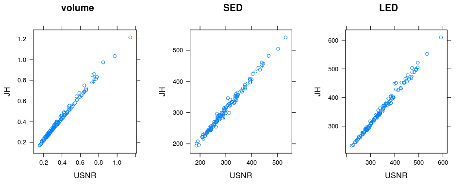

Yep, pretty much.

### 2.1.2 Log SWV

**Hitman SWV isn’t available for the last trimmed log (223). Can we use untrimmed hitman swv?**

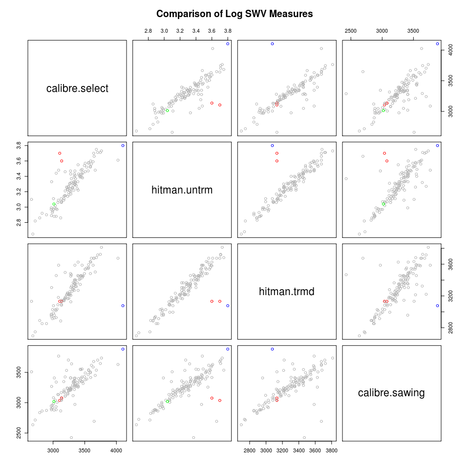

```r
#plot(L$SWV,L$SWV.untrimmed*1000.)
#identify(L$SWV,L$SWV.untrimmed*1000.,L$SWILogNumber)
c=rep('grey70',nrow(L))
c[L$SWILogNumber %in% c(157,183)]='red'
c[L$SWILogNumber %in% c(151)]='blue'
c[L$SWILogNumber %in% c(223)]='green'
tmp=L[,c("velocity","SWV.untrimmed","SWV","velocity.1")]
names(tmp)<-c("calibre.select","hitman.untrm","hitman.trmd","calibre.sawing")
pairs(tmp,col=c,main="Comparison of Log SWV Measures")
```

As well as log 223, there are three outliers (logs 151,157,183).

Trimmed SWV estimate good for logs 157, 183 (i.e. untrimmed SWV wrong).

Use hitman untrimmed estimate for log 151.

Use hitman untrimmed estimate for log 223.

TODO: re-extract hitman SWV from raw hitman data.

```r
L$SWV[L$SWILogNumber==151] = L$SWV.untrimmed[L$SWILogNumber==151]*1000
L$SWV[L$SWILogNumber==223] = L$SWV.untrimmed[L$SWILogNumber==223]*1000
```

### 2.1.3 Log Heartwood

**Is the heartwood volume stuff sane?**

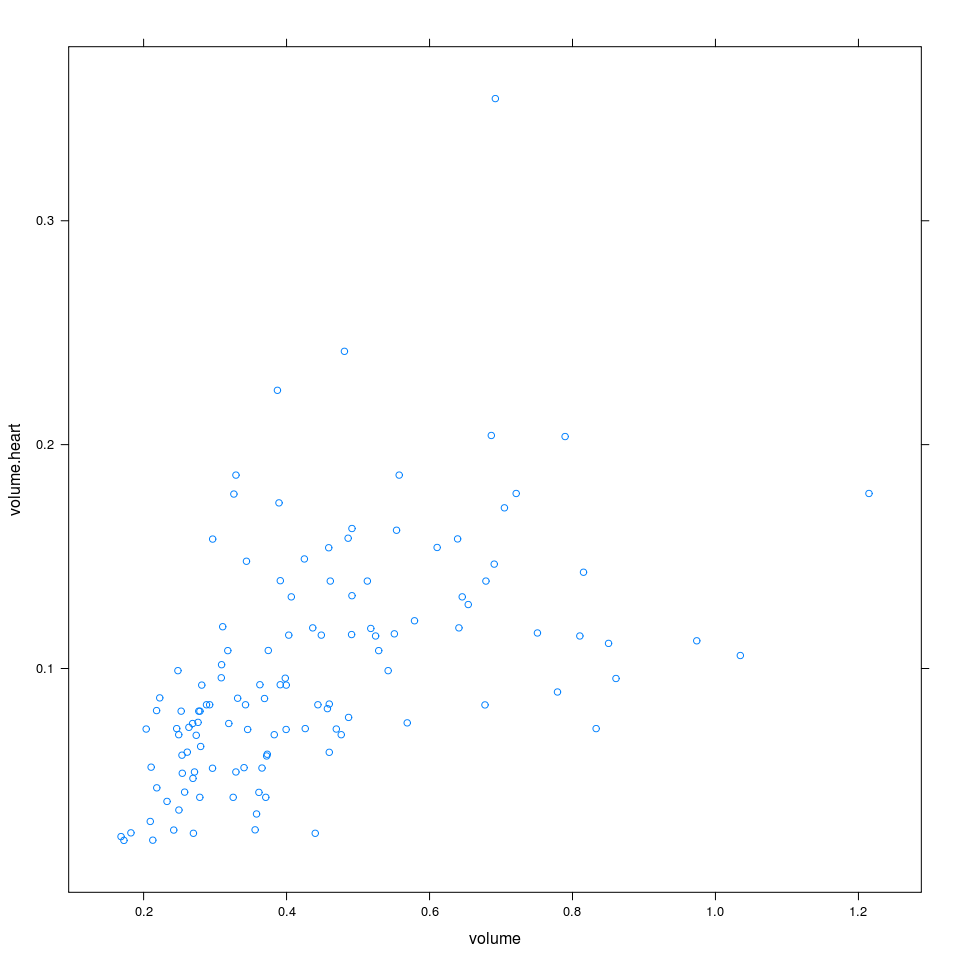

```r
xyplot(volume.heart ~ volume, L)
```

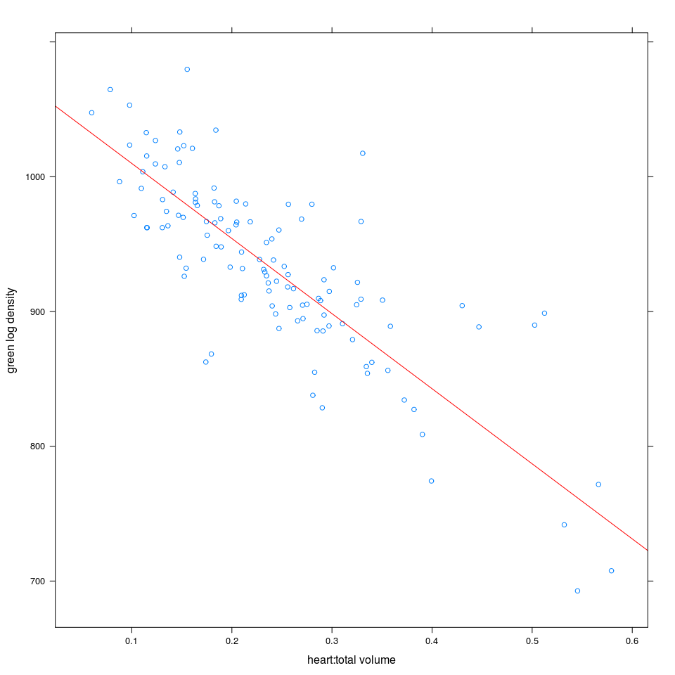

```
##
## Call: rlm(formula = y ~ x)
## Residuals:
##      Min       1Q   Median       3Q      Max
## -106.145  -20.656   -1.598   21.762  136.072
##
## Coefficients:
##             Value     Std. Error t value
## (Intercept) 1065.5776    7.5791   140.5938
## x           -557.1970   28.9969   -19.2157
##
## Residual standard error: 32.05 on 121 degrees of freedom
```

```r
xyplot(density ~ I(volume.heart/volume), L,
       xlab="heart:total volume", ylab="green log density",
       panel=function(x,y,...) {
         print(summary(m<-rlm(y ~ x)))
         panel.xyplot(x,y,...)
         panel.abline(coef(m), col='red')
         })
```

Regression suggests average sapwood density of 1066 kg/m^3, with average heartwood density of 1066-557=509 kg/m^3.

### 2.1.4 Log Shape Metrics

**Why are the shape metrics (`m_*`) missing for 10 logs?**

9 of these logs (198,201,208,195,205,148,194,206,207) were the first put through, maybe the logselect software wasn’t running. The 10th is a log that for some reason couldn’t be matched to Royalty scanner Id (or perhaps no bin file matching that Id was available).

TODO: use metrics computed from bin file, perhaps from another scanner?

**How different are log metrics computed at selection and processing time (i.e. before and after being trimmed to 4.9m)?**

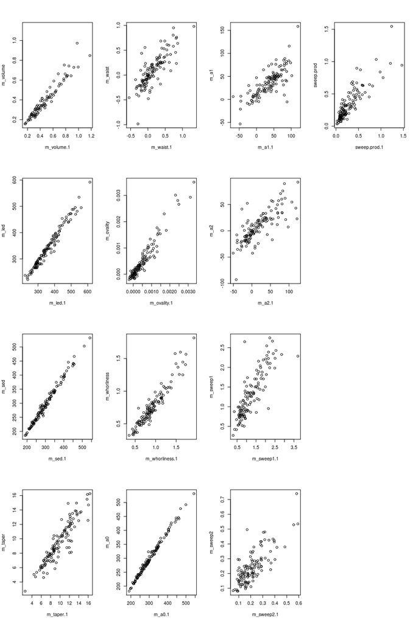

```r
par(mfcol=c(4,4))
log.shape.metrics = c("m_volume","m_led","m_sed","m_taper","m_waist","m_ovality","m_whorliness","m_a0","m_a1","m_a2","m_sweep1","m_sweep2","sweep.prod")
for (m in log.shape.metrics) {
  plot(formula(paste(m,"~",m,".1",sep="")),L)
  }
```

For the most part log metrics **from the same scanner** are similar before and after trimming. Where differences do occur it might be due to:

- the loss of material
- discretization error (incl slight difference in positioning)
- instrument error

## 2.2 Recovery

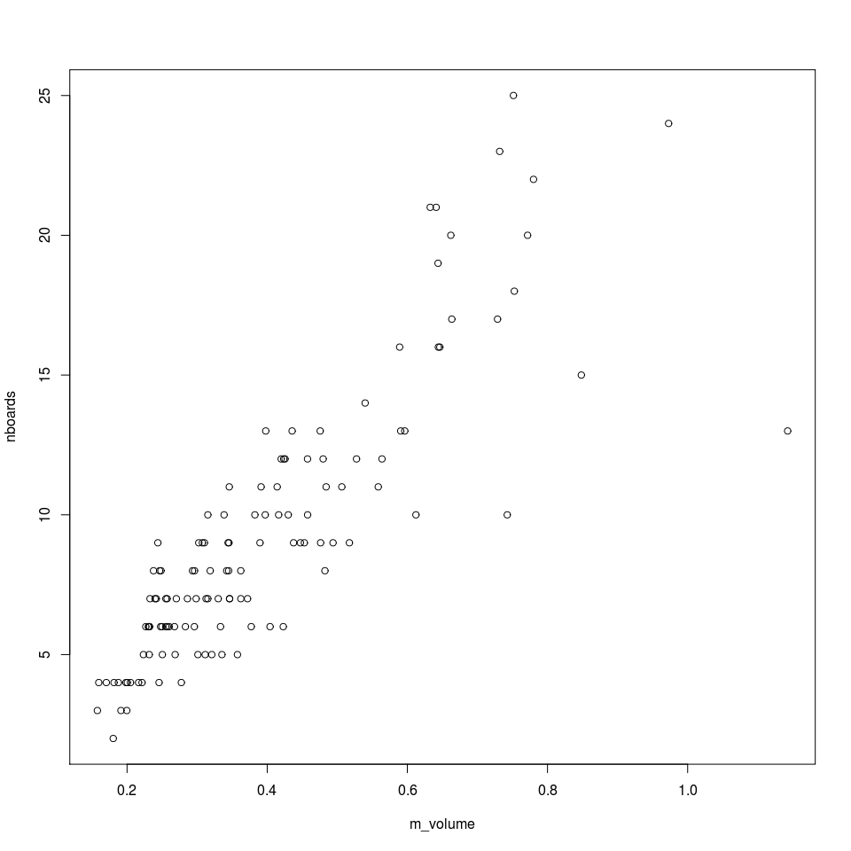

```
## integer(0)
```

```r
plot(nboards ~ m_volume, L)
identify(L$m_volume, L$nboards, L$SWILogNumber, cex=0.8)
```

Two logs with abnormally poor recovery: 126, 192. Either these were sawn to non-90x40 products or gluing was poor and labels were lost.

Exclude these logs from further analysis.

```r
#L = L[!L$SWILogNumber%in%c(106,126,192),]
```

## 2.3 Board Stiffness

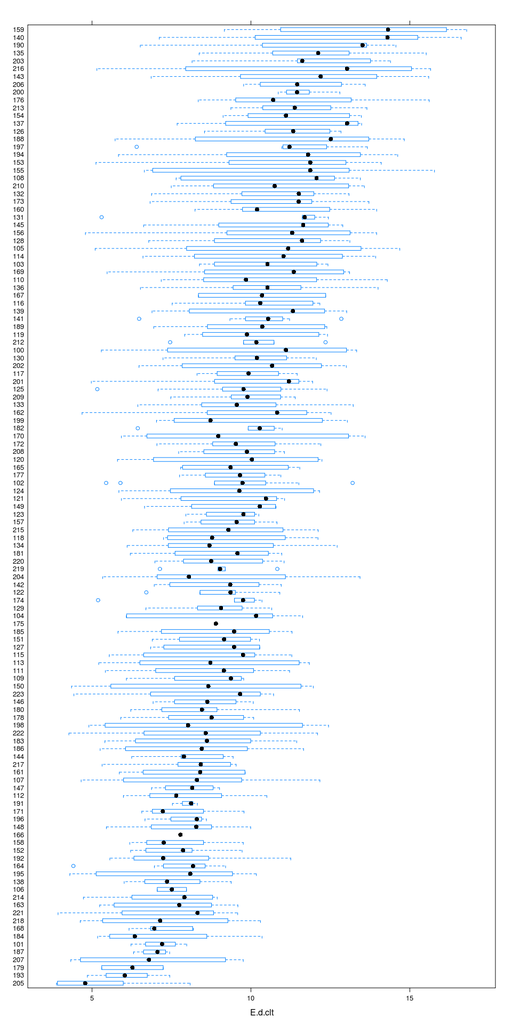

```r
bwplot( factor(SWILogNumber,levels=L$SWILogNumber[order(L$E.avg)],ordered=TRUE) ~ E.d.clt, B)
```

```r
# and again but with only the best and worst and with individual boards
(worst=L$SWILogNumber[L$E.avg<quantile(L$E.avg,0.1)])
```

```
##  [1] 101 106 163 168 179 184 187 193 205 207 214 218 221
```

```r
(best=L$SWILogNumber[L$E.avg>quantile(L$E.avg,0.9)])
```

```
##  [1] 135 137 140 143 154 159 176 190 200 203 206 213 216
```

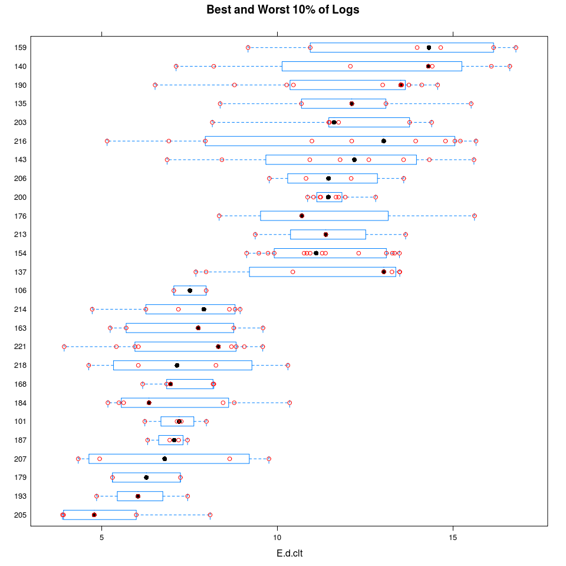

```r
bwplot( factor(SWILogNumber,levels=L$SWILogNumber[order(L$E.avg)],ordered=TRUE) ~ E.d.clt, B,subset=SWILogNumber %in% union(best,worst),
        panel=function(...){
          panel.bwplot(...)
          panel.points(...,col='red')
        }, main="Best and Worst 10% of Logs")
```

The worst (least stiff) boards are similar across all logs. The best (most stiff) boards howver range from <10 GPa to >15GPa.

Are good logs small?

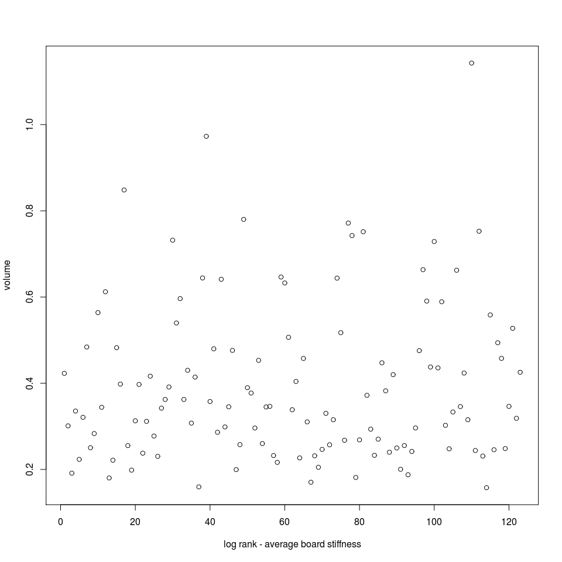

```r
plot(L$m_volume[order(L$E.avg)], xlab="log rank - average board stiffness", ylab="volume")
```

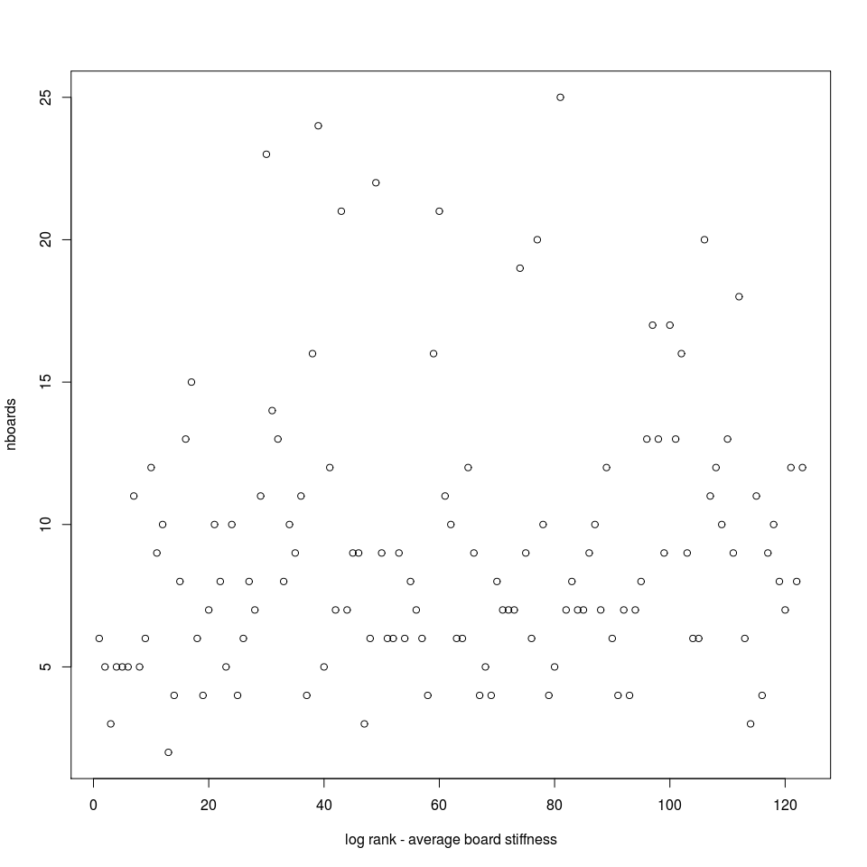

```r
plot(L$nboards[order(L$E.avg)], xlab="log rank - average board stiffness", ylab="nboards")
```

Bad logs tend to be both a little smaller and represented by fewer boards, but the effect is not strong.

## 2.4 Grade

HyneDry data does not include an explicit log grade.

CHH data does, but only “MGP10” and “MGP12” (and “NOGRD” covers the rest)

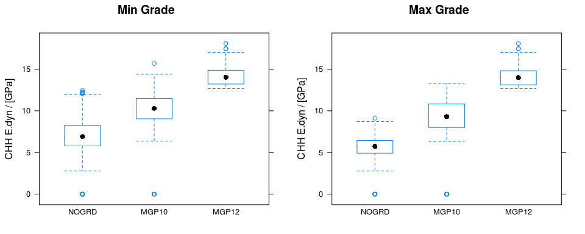

```r
summary(B[,c("chh.grade.min","chh.grade.max")])
```

```
##  chh.grade.min chh.grade.max
##  NOGRD:531     NOGRD:248
##  MGP10:469     MGP10:741
##  MGP12: 96     MGP12:107
##  NA's :106     NA's :106
```

```r
addmargins(table(B$chh.grade.min, B$chh.grade.max))
```

```
##
##         NOGRD MGP10 MGP12  Sum
##   NOGRD   248   283     0  531
##   MGP10     0   458    11  469
##   MGP12     0     0    96   96
##   Sum     248   741   107 1096
```

It is not clear exactly how the CHH grade values relate to measured MOE. Instead lets look at a psuedo-grade.

Note that ‘GPax’ here denotes boards whose average MOE is x GPa or better, which is not the same as having a MGPx grade.

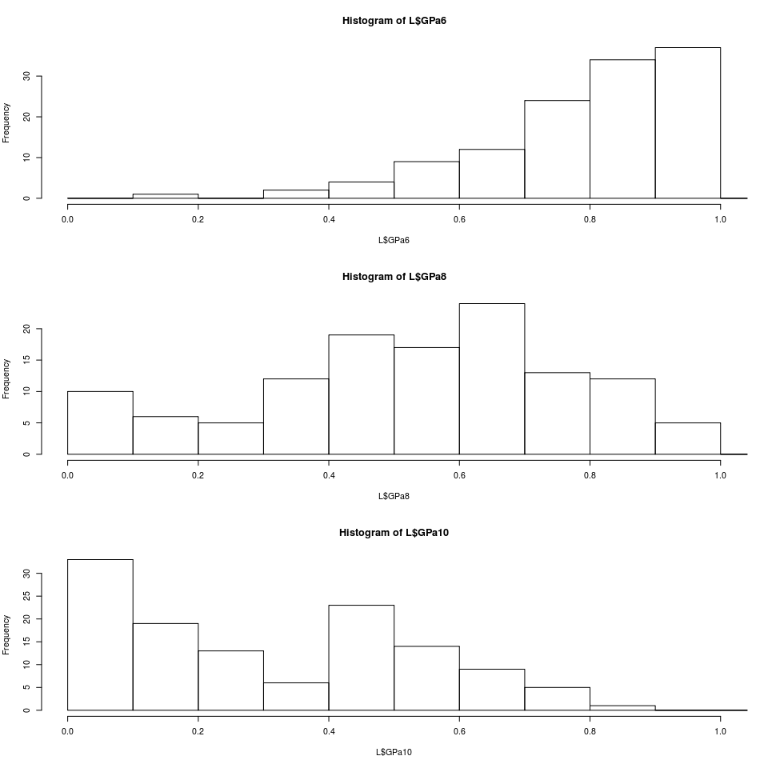

```r
par(mfcol=c(3,1))
hist(L$GPa6, xlim=c(0,1), breaks=c(0:11)/10)
hist(L$GPa8, xlim=c(0,1), breaks=c(0:11)/10)
hist(L$GPa10, xlim=c(0,1), breaks=c(0:11)/10)
```

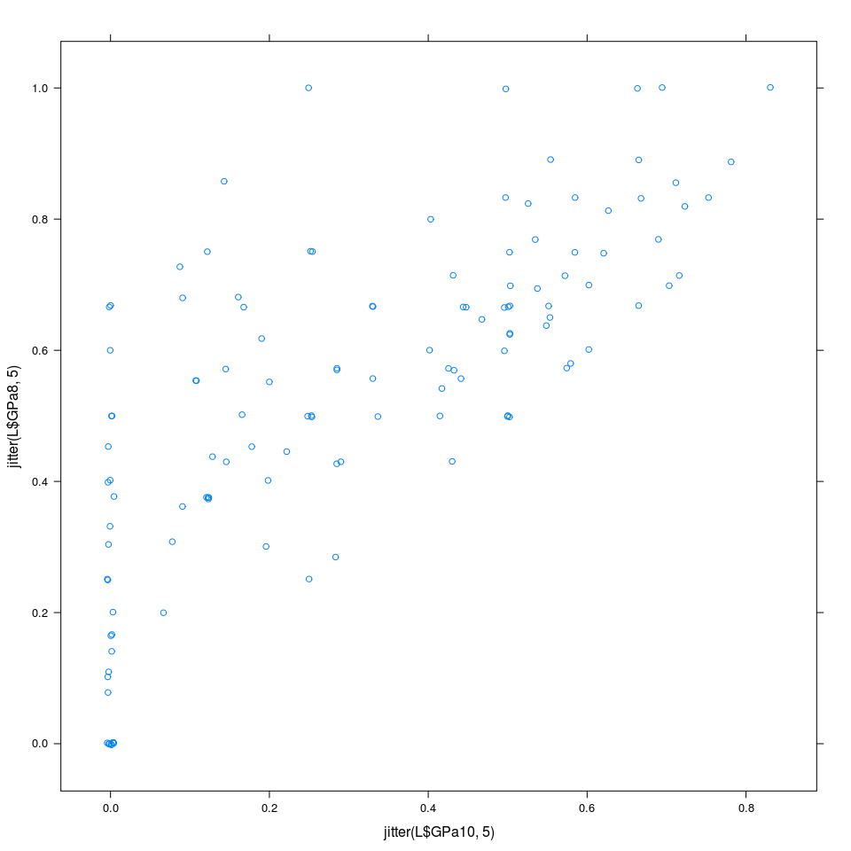

```r
xyplot(jitter(L$GPa8,5)~jitter(L$GPa10,5))
```

Interesting that the 5 best logs if seeking GPa8 include one log that would be in the lower half if you were looking for GPa10.

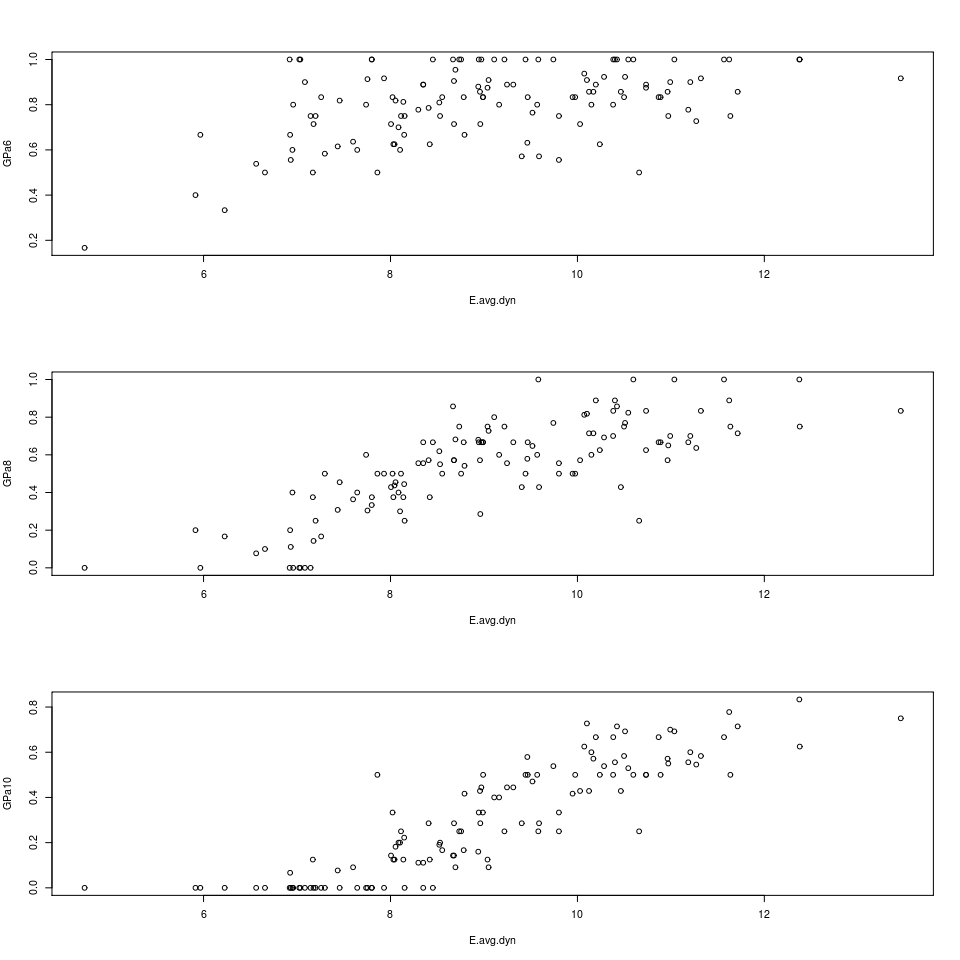

```r
par(mfcol=c(3,1))
plot(GPa6~ E.avg.dyn, L)
plot(GPa8~ E.avg.dyn, L)
plot(GPa10~ E.avg.dyn, L)
```

Log average MOE is not necessarily a good predictor of fraction of boards exceeding a particular MOE limit.

**How does the fraction GPa10+ vary with log quality? I.e. what is the % of GPa10+ in the worst X% of logs?**

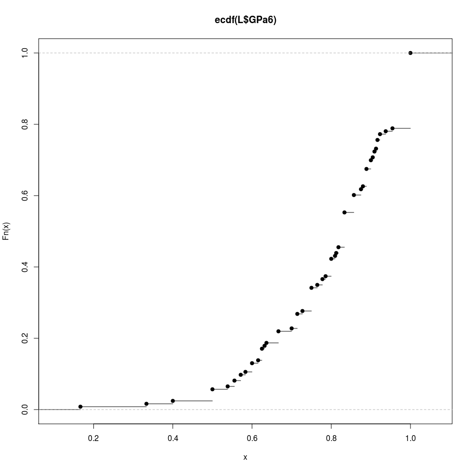

```r
par(mfcol=c(1,1))
F=ecdf(L$GPa6)
plot(F)
```

```r
quantile(L$GPa6, 0.05)
```

```
##        5%
## 0.5038462
```

```r
quantile(L$GPa6, 0.10)
```

```
##       10%
## 0.5866667
```

TODO: using a model for log stiffness based on pre-sawing measures, redo this.

## 2.5 Dynamic v Static

Does it matter if we use Hitman instead of CLT results?

### 2.5.1 Using hitman and CHH density

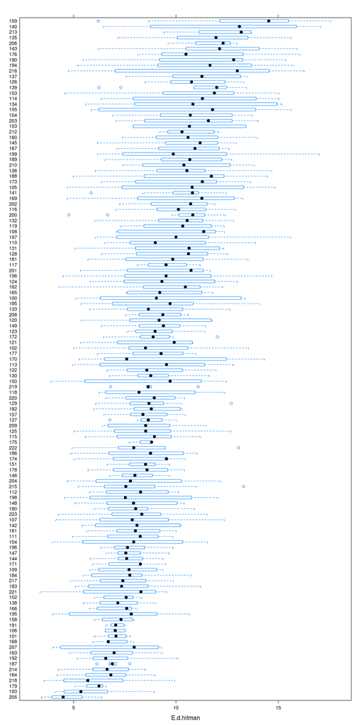

```r
bwplot( factor(SWILogNumber,levels=L$SWILogNumber[order(L$E.avg.dyn)],ordered=TRUE) ~ E.d.hitman, B)
```

```r
# and again but with only the best and worst and with individual boards
(worst.dyn=L$SWILogNumber[L$E.avg<quantile(L$E.avg,0.1)])
```

```
##  [1] 101 106 163 168 179 184 187 193 205 207 214 218 221
```

```r
(best.dyn=L$SWILogNumber[L$E.avg>quantile(L$E.avg,0.9)])
```

```
##  [1] 135 137 140 143 154 159 176 190 200 203 206 213 216
```

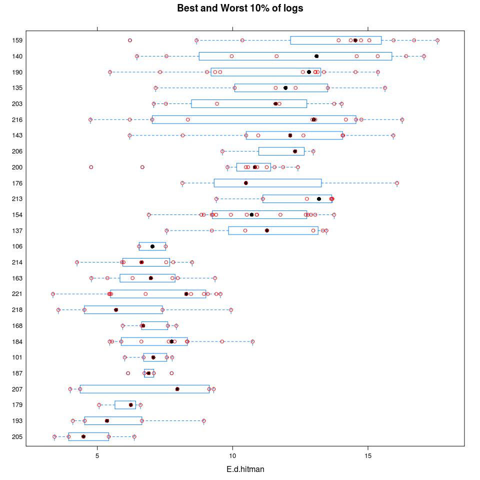

```r
bwplot( factor(SWILogNumber,levels=L$SWILogNumber[order(L$E.avg)],ordered=TRUE) ~ E.d.hitman, B,subset=SWILogNumber %in% union(best.dyn,worst.dyn),
        panel=function(...){
          panel.bwplot(...)
          panel.points(...,col='red')
        }, main="Best and Worst 10% of logs")
```

```r
intersect(best, best.dyn)
```

```
##  [1] 135 137 140 143 154 159 176 190 200 203 206 213 216
```

```r
intersect(worst, worst.dyn)
```

```
##  [1] 101 106 163 168 179 184 187 193 205 207 214 218 221
```

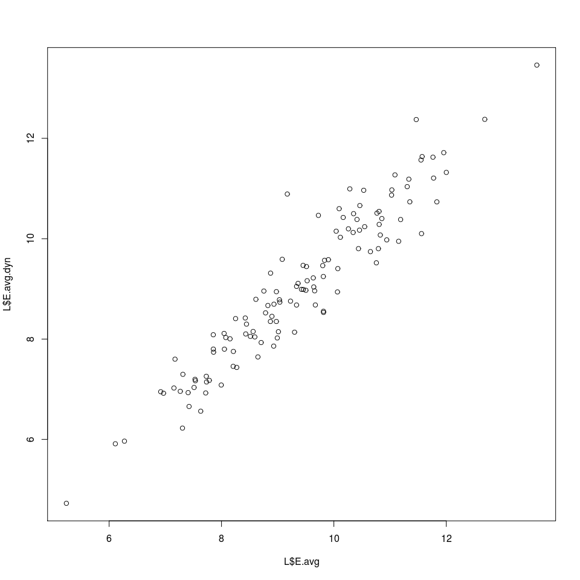

```r
plot(L$E.avg,L$E.avg.dyn)
```

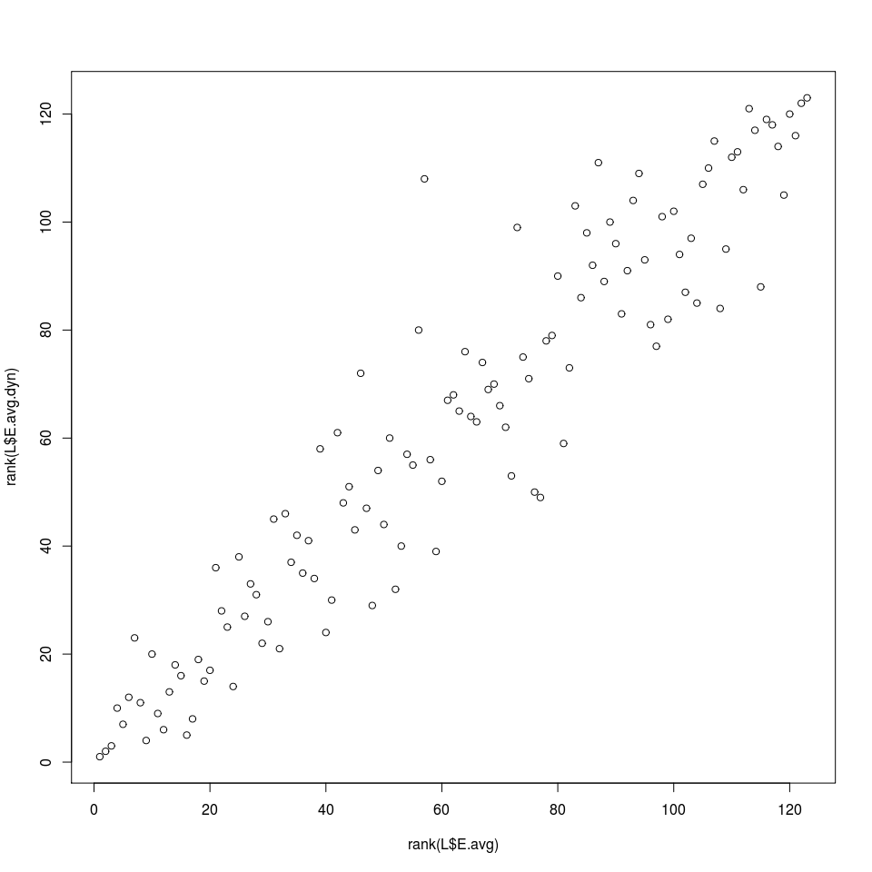

```r
plot(rank(L$E.avg),rank(L$E.avg.dyn))
```

No, we get the same sets of logs as best and worst using either hitman+chh.density or clt for board MOE.

From here on use Hitman and CHH density based board and log average MOE.

## 2.6 Pith Boards

Do all logs have a similar number of pith-in boards?

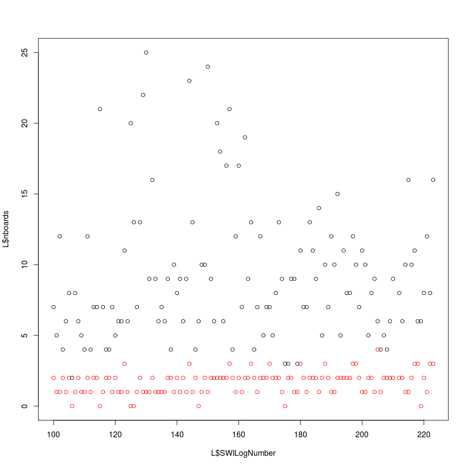

```r
plot(L$SWILogNumber, L$nboards, ylim=c(0,max(L$nboards)))
points(L$SWILogNumber, L$npith, col='red')
```

```r
table(L$npith)
```

```
##
##  0  1  2  3  4
##  7 43 59 13  1
```

```r
L$SWILogNumber[L$npith==0]
```

```
## [1] 106 115 125 126 147 175 219
```

Typically 1 or 2 pith boards per log. BUT 7 logs with no pith boards (either not recovered or not properly classified), this might skew which logs appear to be best and worst. One of these seven is also a worst 10% log so probably not an issue.

Is the fraction of pith boards a good predictor of log average stiffness?

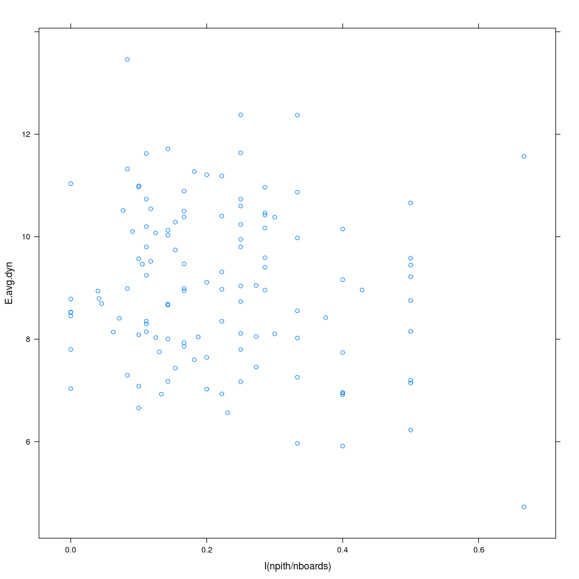

```r
xyplot(E.avg.dyn ~ I(npith/nboards), L)
```

No.

## 2.7 Board Densities

### 2.7.1 Different estimators of dry density

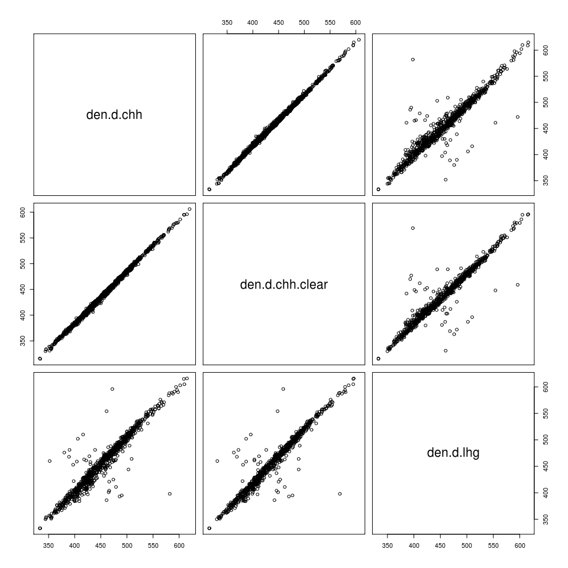

```r
pairs(B[,c('den.d.chh','den.d.chh.clear','den.d.lhg'),])
```

CHH clear (`X_Clear`) and average (`X_Dens`) densities are pretty similar.

Use the latter (`X_Dens`) in conjunction with SWV to estimate MOE.

### 2.7.2 Green vs dry density

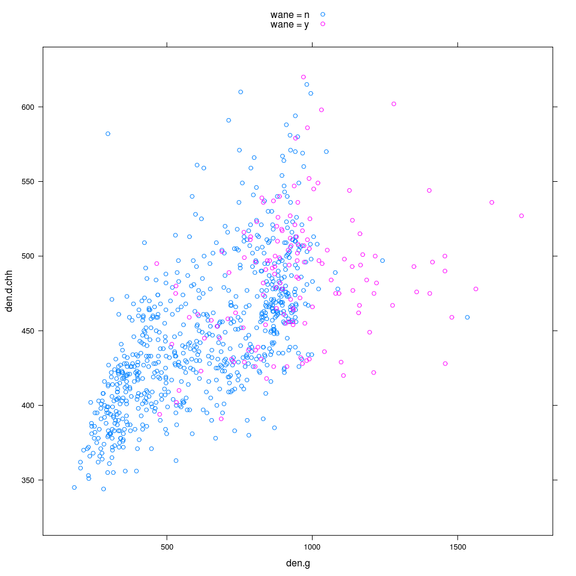

```r
xyplot(den.d.chh ~ den.g, B, group=paste("wane =",wane), auto.key=TRUE)
```

Most of the incredibly high green density boards are waney. Probably the green mass is good, but the green volume is underestimated.

## 2.8 Variation with Distance-from-pith

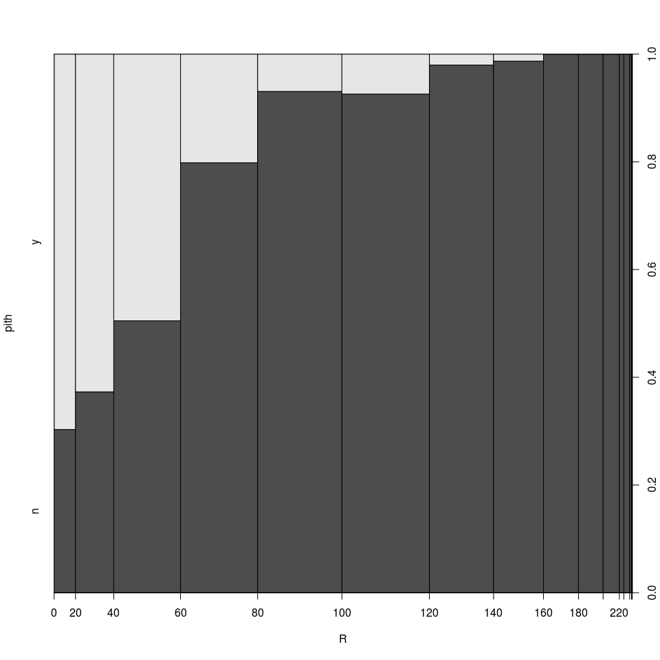

```r
plot(pith ~ R, B)
```

Wow. There are pith containing boards whose LE position is 140-160 mm from pith at LE.

### 2.8.1 Density

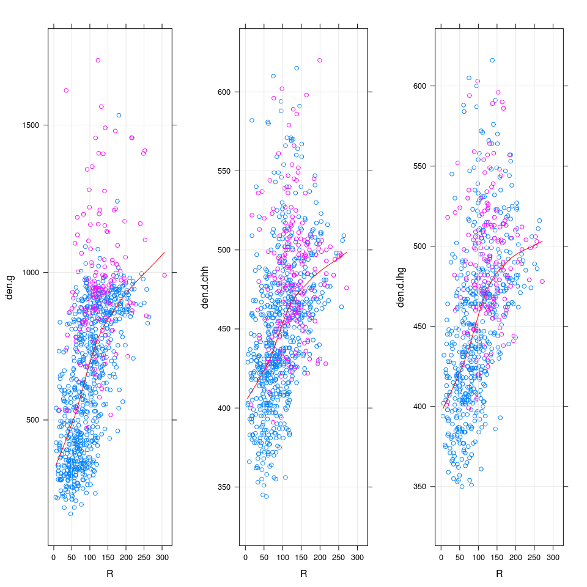

```r
mypanel = function(...) {
  panel.xyplot(...)
  panel.grid(h=-1,v=-1)
  panel.loess(..., col='red')
}

grid.arrange(
  xyplot(den.g ~ R, B, panel=mypanel, group=wane),
  xyplot(den.d.chh ~ R, B, panel=mypanel, group=wane),
  xyplot(den.d.lhg ~ R, B, panel=mypanel, group=wane),
  ncol=3)
```

### 2.8.2 MOE

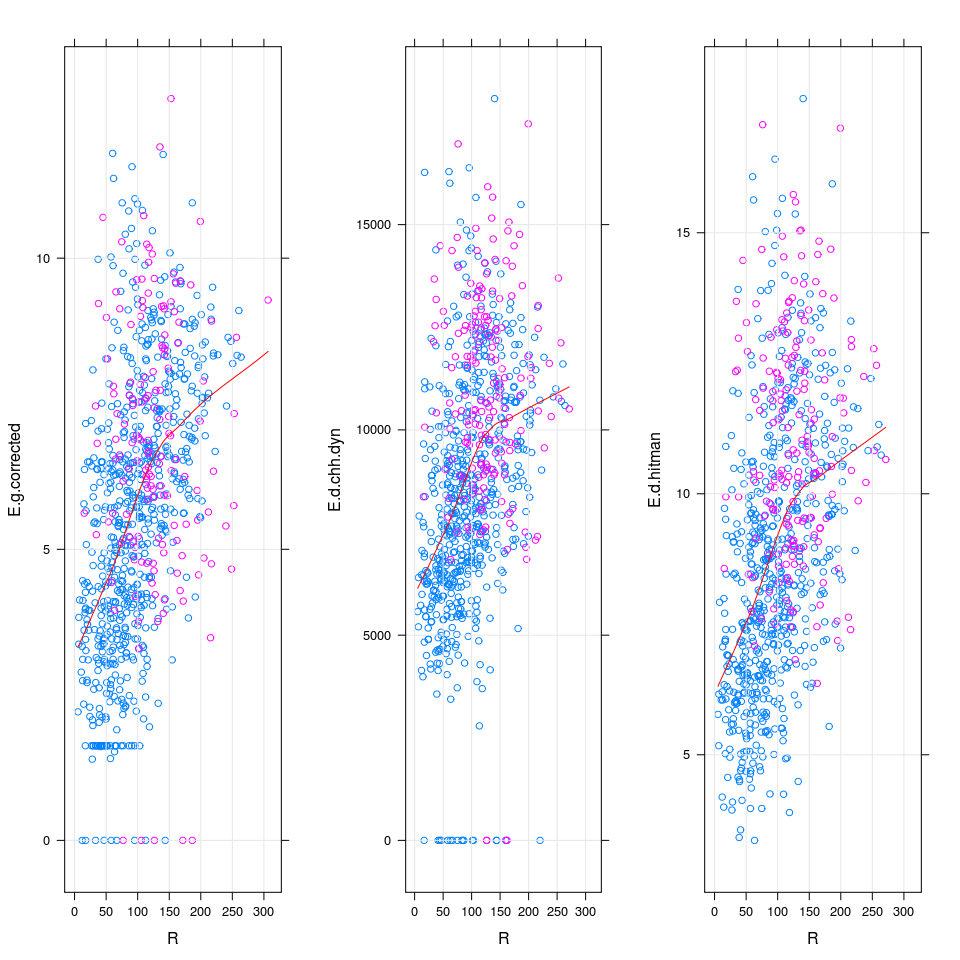

```r
grid.arrange(
  xyplot(E.g.corrected ~ R, B, panel=mypanel, group=wane),
  xyplot(E.d.chh.dyn ~ R, B, panel=mypanel, group=wane),
  xyplot(E.d.hitman ~ R, B, panel=mypanel, group=wane),
  ncol=3)
```

### 2.8.3 Warp

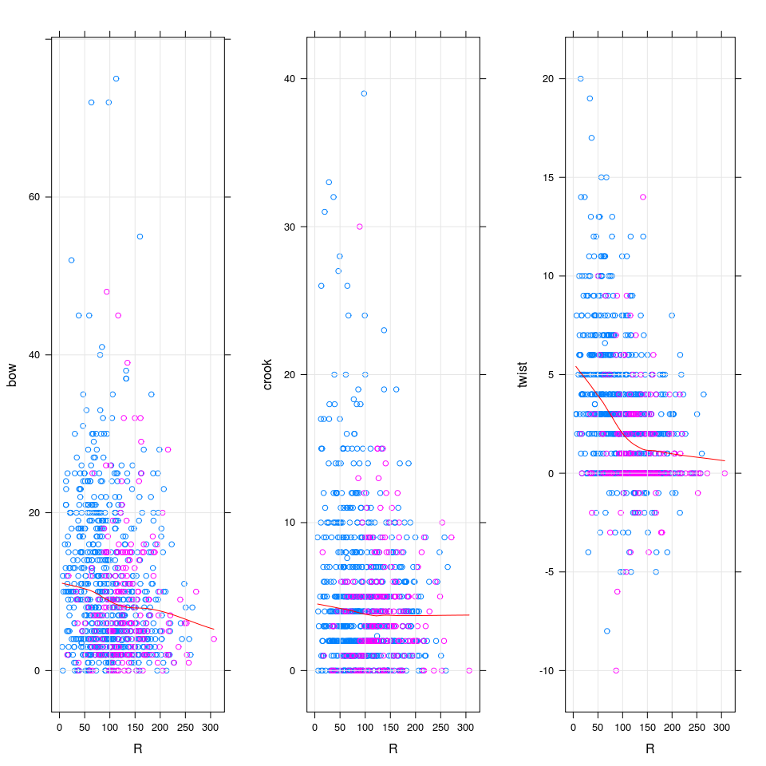

```r
grid.arrange(
  xyplot(bow ~ R, B, panel=mypanel, group=wane),
  xyplot(crook ~ R, B, panel=mypanel, group=wane),
  xyplot(twist ~ R, B, panel=mypanel, group=wane),
  ncol=3)
```

Most of the plots above exhibit a slope discontinuity between $R=100$ and $R=150$ mm.

Lets call boards with $R<100$ ‘inner’ and those with $R>100$ mm ‘outer’.